# PhillyStat360 - OVS Exploratory Analysis & Parcel Drill-Down

MUSA Practicum Team

2026-02-09

## 0. Setup

```r
library(tidyverse)
library(janitor)
library(knitr)
library(scales)
library(patchwork)

data_path <- "../rawdata/"
```

## 1. Load Data

```r
# Primary table: all Philadelphia parcels
properties <- read_csv(paste0(data_path, "opa_properties_public.csv"),
                       show_col_types = FALSE) %>% clean_names()

# Three core OVS sources
clean_seal <- read_csv(paste0(data_path, "clean_seal.csv"),
                       show_col_types = FALSE) %>% clean_names()

violations <- read_csv(paste0(data_path, "violations.csv"),
                       show_col_types = FALSE) %>% clean_names()

licenses <- read_csv(paste0(data_path, "business_licenses.csv"),
                     show_col_types = FALSE) %>% clean_names()

# Supplementary tables
unsafe <- read_csv(paste0(data_path, "unsafe.csv"),
                   show_col_types = FALSE) %>% clean_names()

imm_dang <- read_csv(paste0(data_path, "imm_dang.csv"),
                     show_col_types = FALSE) %>% clean_names()

cat("properties:", comma(nrow(properties)), "rows\n")
```

```
## properties: 583,802 rows
```

```r
cat("clean_seal:", comma(nrow(clean_seal)), "rows\n")
```

```
## clean_seal: 106,040 rows
```

```r
cat("violations:", comma(nrow(violations)), "rows\n")
```

```
## violations: 650,366 rows
```

```r
cat("licenses:", comma(nrow(licenses)), "rows\n")
```

```
## licenses: 425,203 rows
```

```r
cat("unsafe:", comma(nrow(unsafe)), "rows\n")
```

```
## unsafe: 3,292 rows
```

```r
cat("imm_dang:", comma(nrow(imm_dang)), "rows\n")
```

```
## imm_dang: 167 rows
```

## 2. Constructing the Observed Vacancy Status (OVS)

Based on the VacancyGuide2026 methodology and client kickoff meeting, a parcel is classified as OVS=1 (observed vacant) if it meets **any** of the following criteria:

- **Source 1: Clean & Seal** — Property appears in the L+I Clean & Seal records (government-sealed dangerous building)
- **Source 2: Vacant Violations** — Property has specific vacancy-related violation codes with status = ‘OPEN’
- **Source 3: Vacant License** — Property holds an active Vacant Property license

### 2a. Source 1: Clean & Seal Parcels

```r
cs_parcels <- clean_seal %>%
  filter(!is.na(opa_account_num)) %>%
  distinct(opa_account_num) %>%
  mutate(ovs_clean_seal = 1)

cat("Distinct parcels in Clean & Seal:", comma(nrow(cs_parcels)), "\n")
```

```
## Distinct parcels in Clean & Seal: 47,595
```

### 2b. Source 2: Vacant Violations (Currently OPEN)

Per VacancyGuide, only violations with `violationstatus = 'OPEN'` are considered.

```r
# Vacancy-related violation codes per VacancyGuide2026
vacant_viol_codes <- c(
  "9-3904",     # Vacant Lot License
  "9-3905",     # Vacant Structure License
  "PM15-901.1", # Vacant & Open Properties
  "PM15-901.2", # Vacant Properties - Blighted Condition
  "PM15-301",   # Vacant Structure & Land
  "CP-102",     # License - Vacant Lot
  "CP-103",     # License - Vacant Building
  "PM-102.4/1", # License - Vac Lot
  "PM-102.4/2", # License - Vac Res Bldg
  "PM-102.4/3", # License - Vac Wharf/Pier
  "PM-102.4/4"  # License - Vac Comm Bldg
)

viol_parcels <- violations %>%
  filter(violationcode %in% vacant_viol_codes,
         tolower(violationstatus) == "open") %>%
  distinct(opa_account_num) %>%
  filter(!is.na(opa_account_num)) %>%
  mutate(ovs_violation = 1)

cat("Distinct parcels with OPEN vacant violations:", comma(nrow(viol_parcels)), "\n")
```

```
## Distinct parcels with OPEN vacant violations: 4,354
```

```r
# Distribution of OPEN vacant violation codes
violations %>%
  filter(violationcode %in% vacant_viol_codes,
         tolower(violationstatus) == "open") %>%
  count(violationcode, sort = TRUE) %>%
  kable(caption = "Distribution of Currently OPEN Vacant Violation Codes")
```

Distribution of Currently OPEN Vacant Violation Codes

| violationcode | n |
| --- | --- |
| 9-3905 | 3404 |
| PM15-301 | 2984 |
| PM15-901.1 | 1356 |
| PM15-901.2 | 56 |
| 9-3904 | 44 |

### 2c. Source 3: Active Vacant License

```r
# Per VacancyGuide: licensestatus = 'Active' AND revenuecode IN ('3219', '3634')
# 3219 = Residential Vacant License, 3634 = Vacant Commercial Property
vacant_license_parcels <- licenses %>%
  filter(tolower(licensestatus) == "active",
         revenuecode %in% c("3219", "3634")) %>%
  distinct(opa_account_num) %>%
  filter(!is.na(opa_account_num)) %>%
  mutate(ovs_license = 1)

cat("Distinct parcels with Active Vacant License:", comma(nrow(vacant_license_parcels)), "\n")
```

```
## Distinct parcels with Active Vacant License: 1,451
```

### 2d. Merging OVS onto Properties

```r
ovs_df <- properties %>%
  select(parcel_number, location, owner_1, category_code, category_code_description,
         year_built, total_livable_area, market_value, sale_date, sale_price,
         exterior_condition, zoning, zip_code, census_tract) %>%
  left_join(cs_parcels, by = c("parcel_number" = "opa_account_num")) %>%
  left_join(viol_parcels, by = c("parcel_number" = "opa_account_num")) %>%
  left_join(vacant_license_parcels, by = c("parcel_number" = "opa_account_num")) %>%
  replace_na(list(ovs_clean_seal = 0, ovs_violation = 0, ovs_license = 0)) %>%
  mutate(
    ovs = if_else(ovs_clean_seal == 1 | ovs_violation == 1 | ovs_license == 1, 1, 0),
    ovs_sources = ovs_clean_seal + ovs_violation + ovs_license
  )

cat("Total parcels:", comma(nrow(ovs_df)), "\n")
```

```
## Total parcels: 583,802
```

```r
cat("OVS=1 (Observed Vacant):", comma(sum(ovs_df$ovs == 1)), "\n")
```

```
## OVS=1 (Observed Vacant): 48,671
```

```r
cat("OVS=0:", comma(sum(ovs_df$ovs == 0)), "\n")
```

```
## OVS=0: 535,131
```

```r
cat("Vacancy rate:", percent(mean(ovs_df$ovs), accuracy = 0.1), "\n")
```

```
## Vacancy rate: 8.3%
```

## 3. Exploratory Analysis Around OVS

### 3a. OVS Source Overlap

How much do the three sources agree? Are parcels typically flagged by one source or multiple?

```r
ovs_positive <- ovs_df %>% filter(ovs == 1)

cat("=== OVS=1 Source Breakdown ===\n")
```

```
## === OVS=1 Source Breakdown ===
```

```r
cat("Clean & Seal only:", comma(sum(ovs_positive$ovs_clean_seal == 1 & ovs_positive$ovs_violation == 0 & ovs_positive$ovs_license == 0)), "\n")
```

```
## Clean & Seal only: 43,016
```

```r
cat("Violation only:", comma(sum(ovs_positive$ovs_clean_seal == 0 & ovs_positive$ovs_violation == 1 & ovs_positive$ovs_license == 0)), "\n")
```

```
## Violation only: 1,738
```

```r
cat("License only:", comma(sum(ovs_positive$ovs_clean_seal == 0 & ovs_positive$ovs_violation == 0 & ovs_positive$ovs_license == 1)), "\n")
```

```
## License only: 920
```

```r
cat("Two sources overlap:", comma(sum(ovs_positive$ovs_sources == 2)), "\n")
```

```
## Two sources overlap: 2,899
```

```r
cat("All three sources:", comma(sum(ovs_positive$ovs_sources == 3)), "\n")
```

```
## All three sources: 98
```

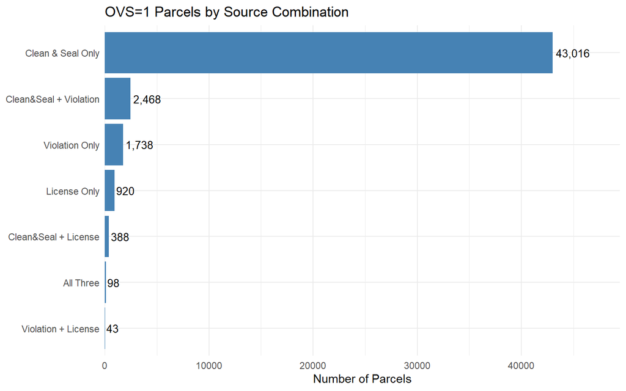

```r
ovs_positive %>%
  mutate(source_combo = case_when(
    ovs_clean_seal == 1 & ovs_violation == 1 & ovs_license == 1 ~ "All Three",
    ovs_clean_seal == 1 & ovs_violation == 1 ~ "Clean&Seal + Violation",
    ovs_clean_seal == 1 & ovs_license == 1 ~ "Clean&Seal + License",
    ovs_violation == 1 & ovs_license == 1 ~ "Violation + License",
    ovs_clean_seal == 1 ~ "Clean & Seal Only",
    ovs_violation == 1 ~ "Violation Only",
    ovs_license == 1 ~ "License Only"
  )) %>%
  count(source_combo, sort = TRUE) %>%
  ggplot(aes(x = reorder(source_combo, n), y = n)) +
  geom_col(fill = "steelblue") +
  geom_text(aes(label = comma(n)), hjust = -0.1, size = 3.5) +
  coord_flip() +
  labs(title = "OVS=1 Parcels by Source Combination",
       x = NULL, y = "Number of Parcels") +
  theme_minimal() +
  scale_y_continuous(expand = expansion(mult = c(0, 0.15)))
```

### 3b. OVS vs. Property Characteristics

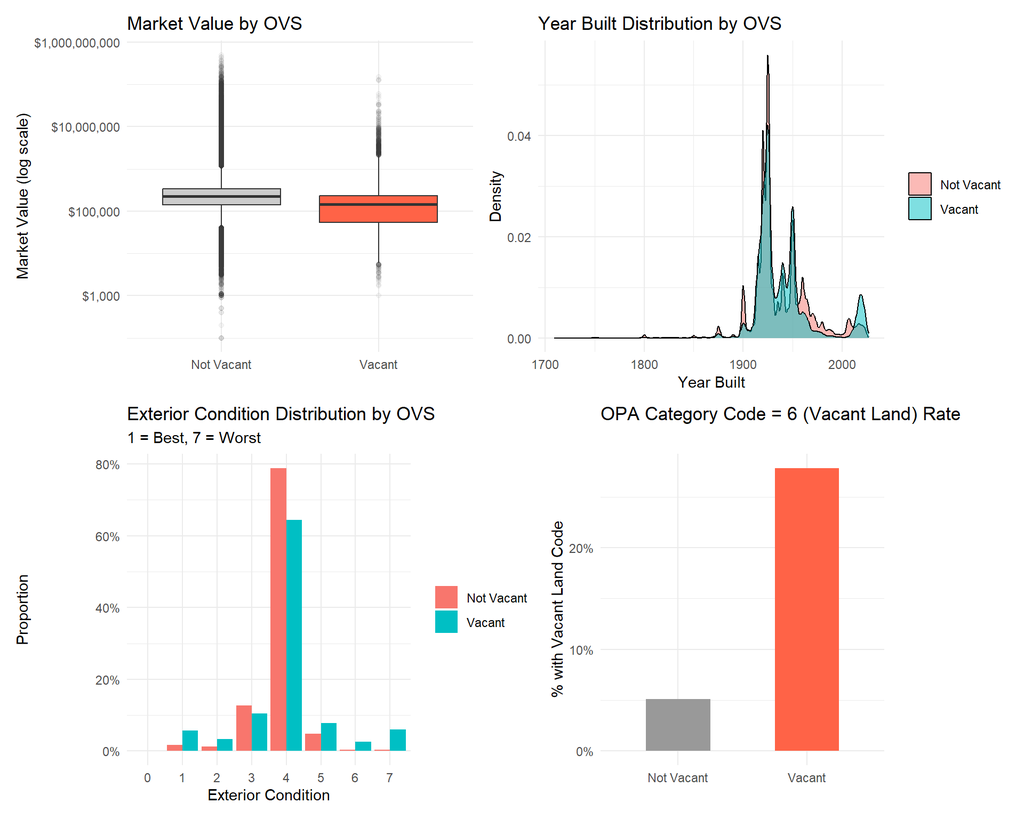

```r
# Market Value comparison (log scale due to extreme skew)
p1 <- ovs_df %>%
  filter(market_value > 0) %>%
  ggplot(aes(x = factor(ovs, labels = c("Not Vacant", "Vacant")),
             y = market_value)) +
  geom_boxplot(fill = c("gray80", "tomato"), outlier.alpha = 0.05) +
  scale_y_log10(labels = dollar) +
  labs(title = "Market Value by OVS", x = NULL, y = "Market Value (log scale)") +
  theme_minimal()

# Year Built comparison
p2 <- ovs_df %>%
  filter(!is.na(year_built), year_built > 1700) %>%
  ggplot(aes(x = year_built, fill = factor(ovs, labels = c("Not Vacant", "Vacant")))) +
  geom_density(alpha = 0.5) +
  labs(title = "Year Built Distribution by OVS",
       x = "Year Built", y = "Density", fill = NULL) +
  theme_minimal()

# Exterior Condition comparison
p3 <- ovs_df %>%
  filter(!is.na(exterior_condition)) %>%
  count(ovs, exterior_condition) %>%
  group_by(ovs) %>%
  mutate(pct = n / sum(n)) %>%
  ggplot(aes(x = factor(exterior_condition), y = pct,
             fill = factor(ovs, labels = c("Not Vacant", "Vacant")))) +
  geom_col(position = "dodge") +
  scale_y_continuous(labels = percent) +
  labs(title = "Exterior Condition Distribution by OVS",
       subtitle = "1 = Best, 7 = Worst",
       x = "Exterior Condition", y = "Proportion", fill = NULL) +
  theme_minimal()

# OPA Category Code = 6 (Vacant Land) rate
p4 <- ovs_df %>%
  mutate(is_vacant_land = category_code == "6") %>%
  count(ovs, is_vacant_land) %>%
  group_by(ovs) %>%
  mutate(pct = n / sum(n)) %>%
  filter(is_vacant_land == TRUE) %>%
  ggplot(aes(x = factor(ovs, labels = c("Not Vacant", "Vacant")), y = pct)) +
  geom_col(fill = c("gray60", "tomato"), width = 0.5) +
  scale_y_continuous(labels = percent) +
  labs(title = "OPA Category Code = 6 (Vacant Land) Rate",
       x = NULL, y = "% with Vacant Land Code") +
  theme_minimal()

(p1 | p2) / (p3 | p4)
```

### 3c. Spatial Distribution of Vacancy (by Zip Code)

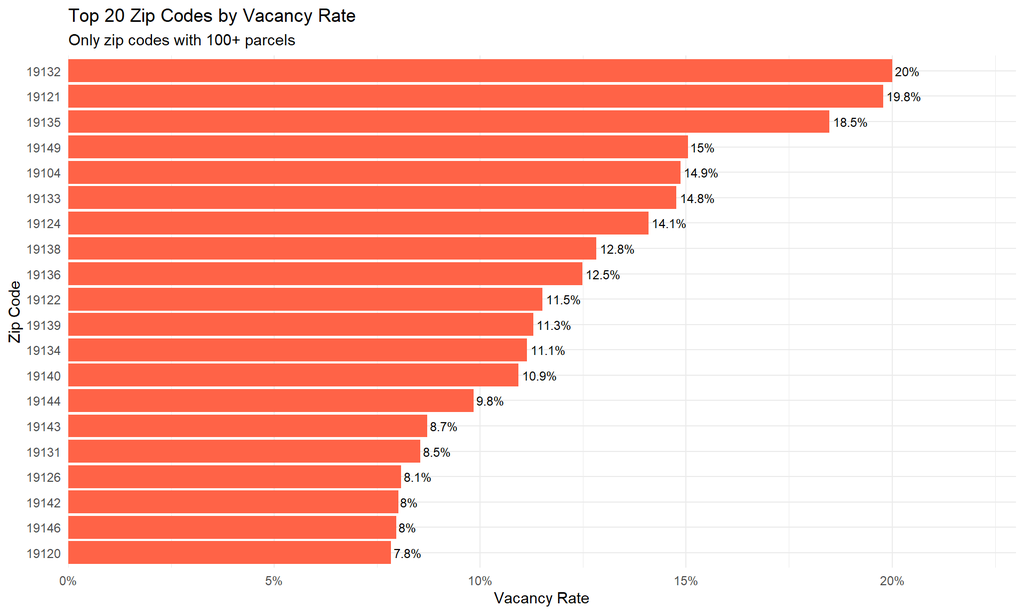

```r
zip_summary <- ovs_df %>%
  filter(!is.na(zip_code)) %>%
  group_by(zip_code) %>%
  summarise(
    total = n(),
    vacant = sum(ovs),
    vacancy_rate = mean(ovs),
    .groups = "drop"
  ) %>%
  filter(total >= 100) %>%
  arrange(desc(vacancy_rate))

zip_summary %>%
  head(20) %>%
  ggplot(aes(x = reorder(as.character(zip_code), vacancy_rate), y = vacancy_rate)) +
  geom_col(fill = "tomato") +
  geom_text(aes(label = paste0(round(vacancy_rate * 100, 1), "%")),
            hjust = -0.1, size = 3) +
  coord_flip() +
  scale_y_continuous(labels = percent, expand = expansion(mult = c(0, 0.15))) +
  labs(title = "Top 20 Zip Codes by Vacancy Rate",
       subtitle = "Only zip codes with 100+ parcels",
       x = "Zip Code", y = "Vacancy Rate") +
  theme_minimal()
```

### 3d. Summary Statistics

```r
ovs_df %>%
  group_by(OVS = factor(ovs, labels = c("Not Vacant (0)", "Vacant (1)"))) %>%
  summarise(
    Count = comma(n()),
    Avg_Market_Value = dollar(mean(market_value, na.rm = TRUE)),
    Median_Market_Value = dollar(median(market_value, na.rm = TRUE)),
    Avg_Year_Built = round(mean(year_built, na.rm = TRUE), 0),
    Avg_Livable_Area = comma(round(mean(total_livable_area, na.rm = TRUE), 0)),
    .groups = "drop"
  ) %>%
  kable(caption = "Feature Comparison: OVS=0 vs OVS=1")
```

Feature Comparison: OVS=0 vs OVS=1

| OVS | Count | Avg_Market_Value | Median_Market_Value | Avg_Year_Built | Avg_Livable_Area |
| --- | --- | --- | --- | --- | --- |
| Not Vacant (0) | 535,131 | $417,090 | $221,800 | 1934 | 2,535 |
| Vacant (1) | 48,671 | $225,506 | $145,600 | 1939 | 2,248 |

## 4. Parcel Drill-Down

We select 2-3 specific parcels representing different vacancy profiles and trace their records across all available datasets to understand how vacancy manifests in the data.

### Helper Function

```r
drill_down <- function(parcel_id) {
  cat("\n========================================\n")
  cat("PARCEL:", parcel_id, "\n")
  cat("========================================\n")

  # --- OPA Properties ---
  prop <- properties %>% filter(parcel_number == parcel_id)
  if (nrow(prop) > 0) {
    cat("\n--- OPA Properties ---\n")
    cat("Address:", prop$location[1], "\n")
    cat("Owner:", prop$owner_1[1], "\n")
    cat("Category:", prop$category_code[1], "-", prop$category_code_description[1], "\n")
    cat("Year Built:", prop$year_built[1], "\n")
    cat("Livable Area:", prop$total_livable_area[1], "sqft\n")
    cat("Market Value: $", comma(prop$market_value[1]), "\n")
    cat("Last Sale:", as.character(prop$sale_date[1]), "  Price: $", comma(prop$sale_price[1]), "\n")
    cat("Exterior Condition:", prop$exterior_condition[1], "(1=Best, 7=Worst)\n")
    cat("Zoning:", prop$zoning[1], "\n")
  } else {
    cat("Not found in OPA Properties table\n")
  }

  # --- Clean & Seal ---
  cs <- clean_seal %>% filter(opa_account_num == parcel_id)
  cat("\n--- Clean & Seal Records (", nrow(cs), ") ---\n")
  if (nrow(cs) > 0) {
    cs %>%
      select(casecreateddate, workordertype, workorderstatus, casecompleteddate) %>%
      arrange(casecreateddate) %>%
      print()
  }

  # --- Violations ---
  viol <- violations %>% filter(opa_account_num == parcel_id)
  cat("\n--- Violation Records (", nrow(viol), ") ---\n")
  if (nrow(viol) > 0) {
    viol %>%
      select(violationdate, violationcode, violationcodetitle,
             violationstatus, mostrecentinvestigation) %>%
      arrange(violationdate) %>%
      print(n = 30)
  }

  # --- Business Licenses ---
  lic <- licenses %>% filter(opa_account_num == parcel_id)
  cat("\n--- Business License Records (", nrow(lic), ") ---\n")
  if (nrow(lic) > 0) {
    lic %>%
      select(licensetype, licensestatus, revenuecode,
             initialissuedate, expirationdate) %>%
      arrange(initialissuedate) %>%
      print()
  }

  # --- Unsafe ---
  uns <- unsafe %>% filter(opa_account_num == parcel_id)
  cat("\n--- Unsafe Structure Records (", nrow(uns), ") ---\n")
  if (nrow(uns) > 0) {
    uns %>%
      select(violationdate, violationcode, violationcodetitle) %>%
      arrange(violationdate) %>%
      print()
  }

  # --- Imminently Dangerous ---
  imd <- imm_dang %>% filter(opa_account_num == parcel_id)
  cat("\n--- Imminently Dangerous Records (", nrow(imd), ") ---\n")
  if (nrow(imd) > 0) {
    imd %>%
      select(violationdate, violationcode, violationcodetitle) %>%
      arrange(violationdate) %>%
      print()
  }
}
```

### 4a. Selecting Target Parcels

We select three cases representing distinct vacancy profiles:

- **Case 1: Severe vacancy** — flagged by all three OVS sources and also in the unsafe structures table
- **Case 2: Violation-only** — flagged only through open violations, no clean & seal or license record
- **Case 3: Potential false negative** — OVS=0 but OPA category_code = ‘6’ (Vacant Land)

```r
# Case 1: Severe vacancy — all three OVS sources + unsafe
case1_candidates <- ovs_df %>%
  filter(ovs_sources == 3) %>%
  filter(parcel_number %in% unsafe$opa_account_num) %>%
  arrange(market_value) %>%
  head(5)

cat("=== Case 1 Candidates (All 3 sources + Unsafe) ===\n")
```

```
## === Case 1 Candidates (All 3 sources + Unsafe) ===
```

```r
case1_candidates %>%
  select(parcel_number, location, market_value, exterior_condition, year_built) %>%
  kable()
```

| parcel_number | location | market_value | exterior_condition | year_built |
| --- | --- | --- | --- | --- |
| 331050800 | 736 E HILTON ST | 26500 | 7 | 1920 |
| 323141300 | 2904 WESTMONT ST | 30000 | 6 | 1915 |
| 132180900 | 4429 N CLEVELAND ST | 30200 | 5 | 1940 |
| 121183410 | 4931-33 SHELDON ST | 54500 | 7 | 1920 |
| 043273400 | 1531 N FRAZIER ST | 98600 | 7 | 1920 |

```r
# Case 2: Violation-only (no clean & seal, no license)
case2_candidates <- ovs_df %>%
  filter(ovs_violation == 1, ovs_clean_seal == 0, ovs_license == 0) %>%
  filter(!is.na(exterior_condition)) %>%
  arrange(desc(market_value)) %>%
  head(5)

cat("\n=== Case 2 Candidates (Violation only, high market value) ===\n")
```

```
##
## === Case 2 Candidates (Violation only, high market value) ===
```

```r
case2_candidates %>%
  select(parcel_number, location, market_value, exterior_condition, year_built) %>%
  kable()
```

| parcel_number | location | market_value | exterior_condition | year_built |
| --- | --- | --- | --- | --- |
| 781051065 | 1025-29 CHESTNUT ST | 47270100 | 4 | 1940 |
| 772025002 | 222-48 N BROAD ST | 20169100 | 4 | 1928 |
| 881448803 | 10200 E ROOSEVELT BLVD | 14525400 | 4 | 1980 |
| 882055250 | 1400 S CHRISTOPHER COLUMBUS BLVD | 10787000 | 4 | 1992 |
| 771637200 | 401-11 S BROAD ST | 8631400 | 4 | 1923 |

```r
# Case 3: Potential false negative — OVS=0 but OPA marks as Vacant Land
set.seed(42)
case3_candidates <- ovs_df %>%
  filter(ovs == 0, category_code == "6") %>%
  filter(market_value > 0) %>%
  sample_n(min(5, n()))

cat("\n=== Case 3 Candidates (OVS=0 but OPA Vacant Land) ===\n")
```

```
##
## === Case 3 Candidates (OVS=0 but OPA Vacant Land) ===
```

```r
case3_candidates %>%
  select(parcel_number, location, market_value, category_code_description) %>%
  kable()
```

| parcel_number | location | market_value | category_code_description |
| --- | --- | --- | --- |
| 404312100 | 7509 CHELWYNDE AVE | 23200 | VACANT LAND |
| 021077100 | 118R CARPENTER ST | 131200 | VACANT LAND |
| 282116901 | 2502 N STANLEY ST | 22300 | VACANT LAND |
| 041000037 | 5408 MASTER ST | 25400 | VACANT LAND |
| 882397019 | 9368-70 OLD BUSTLETON AVE | 99900 | VACANT LAND |

### 4b. Drill-Down Results

#### Case 1: Severe Vacancy

```r
if (nrow(case1_candidates) > 0) {
  drill_down(case1_candidates$parcel_number[1])
}
```

```
##
## ========================================
## PARCEL: 331050800
## ========================================
##
## --- OPA Properties ---
## Address: 736 E HILTON ST
## Owner: EJTLC HOLDINGS LLC
## Category: 1 - SINGLE FAMILY
## Year Built: 1920
## Livable Area: 1126 sqft
## Market Value: $ 26,500
## Last Sale: 2015-01-07 05:00:00   Price: $ 6,500
## Exterior Condition: 7 (1=Best, 7=Worst)
## Zoning: RSA5
##
## --- Clean & Seal Records ( 3 ) ---
## # A tibble: 3 × 4
##   casecreateddate     workordertype  workorderstatus casecompleteddate
##   <dttm>              <chr>          <chr>           <dttm>
## 1 2018-09-07 00:45:15 CLEAN&SEAL     Approved        2018-10-24 16:37:30
## 2 2024-06-13 19:36:44 CLEAN AND SEAL CLOSED          NA
## 3 2024-06-13 19:36:44 CLEAN AND SEAL CANCELLED       NA
##
## --- Violation Records ( 9 ) ---
## # A tibble: 9 × 5
##   violationdate       violationcode violationcodetitle           violationstatus
##   <dttm>              <chr>         <chr>                        <chr>
## 1 2019-04-12 04:00:00 PM15-108.1    UNSAFE STRUCTURE             OPEN
## 2 2019-04-12 04:00:00 PM15-304.1M   EXTERIOR STRUCT UNSAFE COND… OPEN
## 3 2021-03-23 04:00:00 9-3905        VACANT STRUCTURE LICENSE     CLOSED
## 4 2021-03-23 04:00:00 PM15-901.2    VACANT PROPERTIES- BLIGHTED… CLOSED
## 5 2024-06-12 04:00:00 PM15-901.1    VACANT PROPERTIES            COMPLIED
## 6 2024-06-12 04:00:00 PM15-304.3    EXTERIOR STRUCTURE  IDENTIF… OPEN
## 7 2024-06-12 04:00:00 PM15-307      HANDRAILS & GUARDS           OPEN
## 8 2025-04-10 17:37:50 9-3905        VACANT STRUCTURE LICENSE     SVN ISSUED
## 9 2025-12-13 14:42:47 9-3905        VACANT STRUCTURE LICENSE     OPEN
## # ℹ 1 more variable: mostrecentinvestigation <dttm>
##
## --- Business License Records ( 5 ) ---
## # A tibble: 5 × 5
##   licensetype  licensestatus revenuecode initialissuedate    expirationdate
##   <chr>        <chr>               <dbl> <dttm>              <dttm>
## 1 Rental       Inactive             3202 2003-03-17 05:00:00 2004-02-29 05:00:00
## 2 Rental       Inactive             3202 2004-03-02 05:00:00 2010-02-28 05:00:00
## 3 Rental       Inactive             3202 2009-11-05 15:16:14 2011-02-28 05:00:00
## 4 Rental       Inactive             3202 2017-08-16 22:03:49 2018-08-15 04:00:00
## 5 Vacant Resi… Active               3219 2026-01-09 15:05:31 2027-01-08 15:05:31
##
## --- Unsafe Structure Records ( 1 ) ---
## # A tibble: 1 × 3
##   violationdate       violationcode violationcodetitle
##   <dttm>              <chr>         <chr>
## 1 2019-04-12 04:00:00 PM15-108.1    UNSAFE STRUCTURE
##
## --- Imminently Dangerous Records ( 0 ) ---
```

#### Case 2: Violation-Only

```r
if (nrow(case2_candidates) > 0) {
  drill_down(case2_candidates$parcel_number[1])
}
```

```
##
## ========================================
## PARCEL: 781051065
## ========================================
##
## --- OPA Properties ---
## Address: 1025-29 CHESTNUT ST
## Owner: PHILA PARKING AUTHORITY
## Category: 4 - COMMERCIAL
## Year Built: 1940
## Livable Area: 147208 sqft
## Market Value: $ 47,270,100
## Last Sale: 1943-01-01 04:00:00   Price: $ 1
## Exterior Condition: 4 (1=Best, 7=Worst)
## Zoning: CMX5
##
## --- Clean & Seal Records ( 0 ) ---
##
## --- Violation Records ( 8 ) ---
## # A tibble: 8 × 5
##   violationdate       violationcode violationcodetitle           violationstatus
##   <dttm>              <chr>         <chr>                        <chr>
## 1 2024-05-08 04:00:00 F-912.4.1     "FDC LOCKING CAPS\r\n"       COMPLIED
## 2 2024-05-08 04:00:00 F-912.5       "FDC SIGNAGE REQUIRED\r\n"   OPEN
## 3 2024-05-08 04:00:00 F-912.7       "FDC INSPECTION, TESTING & … OPEN
## 4 2024-05-08 04:00:00 F-903.5       "SUPPRESSION SYSTEM TESTING… OPEN
## 5 2024-05-08 04:00:00 PM15-302.9    "EXTERIOR AREA GRAFFITI"     OPEN
## 6 2024-05-08 04:00:00 F-901.6.4.2   "SUBMISSION OF CERTIFICATIO… OPEN
## 7 2024-05-08 04:00:00 F-505.1       "ADDRESS IDENTIFICATION\r\n" OPEN
## 8 2024-05-08 04:00:00 PM15-901.1    "VACANT PROPERTIES"          OPEN
## # ℹ 1 more variable: mostrecentinvestigation <dttm>
##
## --- Business License Records ( 2 ) ---
## # A tibble: 2 × 5
##   licensetype  licensestatus revenuecode initialissuedate    expirationdate
##   <chr>        <chr>               <dbl> <dttm>              <dttm>
## 1 Dumpster Li… Active               3230 2012-03-21 13:33:02 NA
## 2 Public Gara… Active               3371 2012-04-26 16:00:36 2026-12-31 05:00:00
##
## --- Unsafe Structure Records ( 0 ) ---
##
## --- Imminently Dangerous Records ( 0 ) ---
```

#### Case 3: Potential False Negative

```r
if (nrow(case3_candidates) > 0) {
  drill_down(case3_candidates$parcel_number[1])
}
```

```
##
## ========================================
## PARCEL: 404312100
## ========================================
##
## --- OPA Properties ---
## Address: 7509 CHELWYNDE AVE
## Owner: MC GOVERN EUGENE J JR
## Category: 6 - VACANT LAND
## Year Built: NA
## Livable Area: NA sqft
## Market Value: $ 23,200
## Last Sale: 1989-06-07 04:00:00   Price: $ 1
## Exterior Condition: NA (1=Best, 7=Worst)
## Zoning: RSA3
##
## --- Clean & Seal Records ( 0 ) ---
##
## --- Violation Records ( 0 ) ---
##
## --- Business License Records ( 0 ) ---
##
## --- Unsafe Structure Records ( 0 ) ---
##
## --- Imminently Dangerous Records ( 0 ) ---
```

## 5. Preliminary Findings

### OVS Overview

- **Overall vacancy rate: ~8.3%** (48,671 out of 583,802 parcels)
- Clean & Seal is the dominant source, contributing ~88% of all OVS=1 parcels on its own
- Violation and License sources have limited independent coverage (1,738 and 920 parcels respectively)
- Very few parcels are flagged by all three sources (98), suggesting the sources capture different aspects of vacancy

### Drill-Down Insights

- **Case 1** (severe vacancy) illustrates a typical deterioration trajectory: formerly rented property → rental license lapses → sealed by Clean & Seal → unsafe structure designation → recurring vacant violation citations
- **Case 2** (violation-only) reveals potential false positives in our OVS definition — commercial properties like parking garages may be flagged as “vacant” through PM15-901.1 violations despite active use
- **Case 3** (potential false negative) shows properties that OPA classifies as vacant land but that have no current active indicators in our three OVS sources — these may be captured once water utility data is integrated

### Implications for Modeling

- The Clean & Seal source may need **temporal filtering** — a property sealed in 2010 may no longer be vacant in 2026
- **Building vs. Land** separation is critical: the OPA category_code field can serve as the initial split
- Commercial properties and parking lots may need special handling to avoid systematic false positives
- Water utility data (pending from client) will likely capture a significant number of false negatives, particularly for vacant land parcels